# Conceptos básicos de Estadística

Autor/a

Afiliación

Óscar Fernando González Barrera  
Rosa del Pilar Moncayo González

[Escuela Superior de Administración Pública](https://www.esap.edu.co/)

# 1. Historia de la Estadística

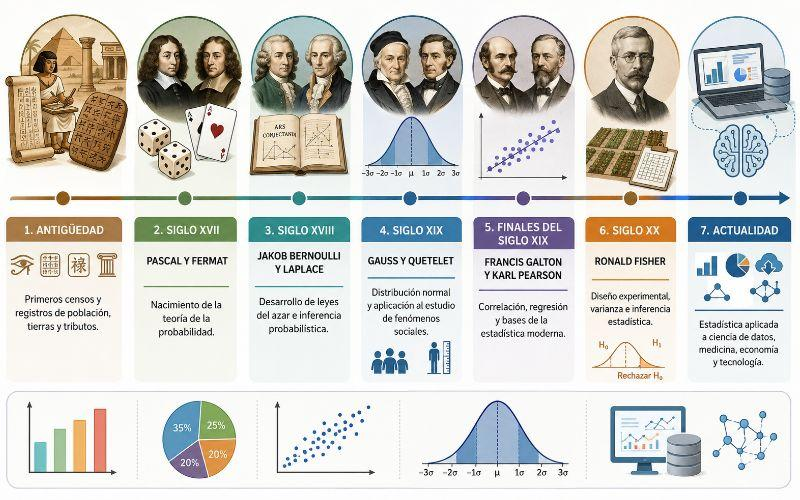

| Época / pueblo | Aporte |
| --- | --- |
| Prehistoria (≈ 8000 a. C.) | Gráficos y símbolos en pieles, rocas, maderas y cuevas para contar personas, animales o cosas. En Cerdeña, los Nuragas hacían muescas para contar ganado y caza. |
| Egipto (≈ 3050 a. C.) | Censos y análisis de población y renta, antes de construir las pirámides. |
| Babilonia (≈ 3000 a. C.) | Tablillas de arcilla con datos de producción agrícola y de bienes vendidos o trocados. |
| China (2238 a. C.) | El emperador Yao ordenó una estadística agrícola, industrial y comercial; hay censos de hace más de cuarenta siglos. |
| Asiria | Sargón II fundó la biblioteca de Nínive, con datos de producción, cuentas, medicina y astronomía. |
| Biblia | Censo de Moisés (libro de Números). |
| Grecia | Observaciones sobre tierras y servicio militar; unos 69 censos con fines tributarios, sociales y militares. |
| Roma | Censo cada cinco años; registro de nacimientos, defunciones, matrimonios, ganado y riquezas de tierras conquistadas. |
| Edad Media | Casi olvidada; destacan los registros de tierras de la Iglesia (Pipino el Breve, 758; Carlomagno, 762). |
| Incas (1200-1527 d. C.) | Registraban nacimientos, defunciones y población por edad y sexo usando *quipus* (cuerdas con nudos). |
| Iglesia (s. XVI) | Tras el Concilio de Trento, obligación de inscribir nacimientos, matrimonios y defunciones. |
| Siglo XVII | Graunt (1662) analiza las *Bills of Mortality* y hace predicciones; Neumann (1691) refuta que en años terminados en siete muera más gente; Halley construye tablas de mortalidad. |
| Siglos XVII-XVIII | Bernoulli, Maseres, Lagrange y Laplace desarrollan la teoría de probabilidades. |
| Siglo XIX | Quételet aplica el método estadístico a las ciencias sociales; Laplace, Gauss y Legendre desarrollan la teoría de errores y los mínimos cuadrados. |
| Siglo XX hasta hoy | La computación transforma la disciplina (Benzécri en Francia, Tukey en EE. UU.); la estadística pasa de tabular datos a interpretarlos. |

Tres grandes fases: (1) los censos, (2) de la descripción de conjuntos a la aritmética política y (3) estadística y cálculo de probabilidades.

# 2. Conceptos fundamentales

[figure not shown]

**Estadística.** Ciencia que recoge, organiza, presenta, analiza e interpreta datos para tomar decisiones más eficaces.

- **Estadística descriptiva:** organiza, resume y presenta datos de manera informativa (cuadros, gráficos, promedios).
- **Estadística inferencial (inductiva):** determina propiedades de una población a partir de una muestra, y permite pronosticar.

[output not shown]

**¿Por qué se toman muestras?** Por costo, por tiempo y porque algunas pruebas destruyen el objeto (control de calidad, un hemograma).

**NotaFuentes e instrumentos**

**Fuentes.** *Primarias:* datos obtenidos directamente de la persona o entidad. *Secundarias:* datos tomados de publicaciones.

**Instrumentos:** encuestas, entrevistas, cuestionarios, observación, control de calidad y reportes de producción.

**Fenómenos que estudia la estadística.** Son colectivos (no casos individuales), de frecuente repetición, de distinta frecuencia, observables (se manifiestan al exterior) y cuantificables.

# 3. Variables según su naturaleza

[figure not shown]

La información recolectada se almacena en **variables**.

- **Cualitativas (atributos):** no numéricas, o numéricas solo como código (no miden nada). Ej.: género, estado civil, marca, color de ojos.
- **Cuantitativas:** se pueden medir.
  - **Discretas:** cuentan, suelen ser enteros. Ej.: camas de un hospital, empleados de una fábrica.
  - **Continuas:** miden, admiten decimales. Ej.: temperatura, estatura, litros de leche.

**NotaVer ejemplo en R**

```r
estado_civil <- factor(c("Soltero", "Casado", "Otro", "Casado"))  # cualitativa
camas        <- c(120L, 85L, 40L)                                  # discreta
temperatura  <- c(36.5, 37.2, 38.1)                                # continua

sapply(list(estado_civil = estado_civil, camas = camas, temperatura = temperatura), class)
```

```
estado_civil        camas  temperatura
    "factor"    "integer"    "numeric"
```

# 4. Variables según la escala de medición

El nivel de medición determina qué cálculos y pruebas son apropiados.

**Nominal**

Los datos solo se clasifican y se cuentan; el orden es convencional.

- **Ejemplos:** marca de automóvil, número de camiseta.
- **En R:** `factor()`

**Ordinal**

Los datos se ordenan, pero la distancia entre categorías no es medible.

- **Ejemplos:** nivel educativo, posición en una lista.
- **En R:** `factor(ordered = TRUE)`

**Intervalo**

Diferencias iguales significan diferencias iguales en la medición; el cero es relativo.

- **Ejemplos:** temperatura en °C, coeficiente intelectual, talla de ropa.
- **En R:** `numeric`

**Razón**

Como el intervalo, pero con cero absoluto (“no hay”) y razones con sentido.

- **Ejemplos:** dinero, longitud, peso, pacientes atendidos.
- **En R:** `numeric`

**NotaVer ejemplo en R**

```r
nivel <- factor(
  c("Primaria", "Superior", "Secundaria", "Primaria"),
  levels  = c("Sin nivel", "Primaria", "Secundaria", "Superior"),
  ordered = TRUE
)
nivel
```

```
[1] Primaria   Superior   Secundaria Primaria
Levels: Sin nivel < Primaria < Secundaria < Superior
```

```r
table(nivel)
```

```
nivel
 Sin nivel   Primaria Secundaria   Superior
         0          2          1          1
```